# SN_01_LTD_RECIP_ADDR_CITY

Recipient city · Text report

## Overview

**Description**

Address Foreign - City

**Table**

`SN-P01-T01-LIQUIDATION-TERMINATION-DISSOLUTION` (many)

**Location code**

`SCHED-N-PART-01-LINE-01-COL-F`

**Family**

`SCHED-N-PART-01-LINE-01-COL-F` · siblings: SN_01_LTD_RECIP_ADDR_CNTR, SN_01_LTD_RECIP_ADDR_L1, SN_01_LTD_RECIP_ADDR_L2, SN_01_LTD_RECIP_ADDR_STATE, SN_01_LTD_RECIP_ADDR_ZIP, SN_01_LTD_RECIP_NAME_ORG_L1

**Data type**

text (xsd: , TextType, CityType)

**Scope**

PZ

**Status**

unreviewed

10

xpaths mapped (6 observed)

30,455

filings with a value

2009–2024

tax years observed

10

open flags (1 errors)

## Flags

| Severity | Flag | Xpath | Detail |
| --- | --- | --- | --- |
| ⚠ error | `COLLISION` | IRS990ScheduleN/LiquidationOfAssetsTableGrp/LiquidationOfAssetsDetail/ForeignAddress/CityNm | 62 filings contain 2+ of its xpaths; most common set: /Return/ReturnData/IRS990ScheduleN/LiquidationOfAssetsTableGrp/LiquidationOfAssetsDetail/ForeignAddress/CityNm ; /Return/ReturnData/IRS990Schedule… |
| ⓘ info | `MANY_NOT_REPEATING` | IRS990ScheduleN/LiquidationOfAssetsTableGrp/LiquidationOfAssetsDetail/USAddress/CityNm | many-to-one table, but 66% of values sit in no repeating element |
| ⓘ info | `MANY_NOT_REPEATING` | IRS990ScheduleN/LiquidationTable/LiquidationDetail/AddressUS/City | many-to-one table, but 63% of values sit in no repeating element |
| ⓘ info | `MANY_NOT_REPEATING` | IRS990ScheduleN/LiquidationOfAssetsTableGrp/LiquidationOfAssetsDetail/USAddress/City | many-to-one table, but 61% of values sit in no repeating element |
| ⓘ info | `MANY_NOT_REPEATING` | IRS990ScheduleN/LiquidationOfAssetsTableGrp/LiquidationOfAssetsDetail/ForeignAddress/CityNm | many-to-one table, but 60% of values sit in no repeating element |
| ⓘ info | `MANY_NOT_REPEATING` | IRS990ScheduleN/LiquidationTable/LiquidationDetail/AddressForeign/City | many-to-one table, but 58% of values sit in no repeating element |
| ⓘ info | `UNOBSERVED` | IRS990ScheduleN/Form990ScheduleNPartI/LiquidationTable/AddressForeign/City | never observed in TY2009-2024 filings |
| ⓘ info | `UNOBSERVED` | IRS990ScheduleN/Form990ScheduleNPartI/LiquidationTable/AddressUS/City | never observed in TY2009-2024 filings |
| ⓘ info | `UNOBSERVED` | IRS990ScheduleN/LiquidationTable/AddressForeign/City | never observed in TY2009-2024 filings |
| ⓘ info | `UNOBSERVED` | IRS990ScheduleN/LiquidationTable/AddressUS/City | never observed in TY2009-2024 filings |

## Xpaths

All mapped xpaths (under /Return/ReturnData or /Return/ReturnHeader), oldest first. Charts label each series by its xpath.

| Xpath | Form | Chart label | First year | Last year | Versions | Filings | Repeats in |
| --- | --- | --- | --- | --- | --- | --- | --- |
| IRS990ScheduleN/LiquidationTable/LiquidationDetail/AddressUS/City | Sched N | …heduleN/LiquidationTable/LiquidationDetail/AddressUS/City | 2009 | 2012 | 16 | 2,980 | 36.3% |
| IRS990ScheduleN/LiquidationTable/LiquidationDetail/AddressForeign/City | Sched N | …eN/LiquidationTable/LiquidationDetail/AddressForeign/City | 2010 | 2012 | 7 | 12 | 16.7% |
| IRS990ScheduleN/LiquidationOfAssetsTableGrp/LiquidationOfAssetsDetail/USAddress/City | Sched N | …OfAssetsTableGrp/LiquidationOfAssetsDetail/USAddress/City | 2013 | 2013 | 3 | 1,429 | 37.9% |
| IRS990ScheduleN/LiquidationOfAssetsTableGrp/LiquidationOfAssetsDetail/ForeignAddress/City | Sched N | …etsTableGrp/LiquidationOfAssetsDetail/ForeignAddress/City | 2013 | 2013 | 3 | 7 | 28.6% |
| IRS990ScheduleN/LiquidationOfAssetsTableGrp/LiquidationOfAssetsDetail/USAddress/CityNm | Sched N | …AssetsTableGrp/LiquidationOfAssetsDetail/USAddress/CityNm | 2014 | 2024 | 34 | 25,817 | 33.7% |
| IRS990ScheduleN/LiquidationOfAssetsTableGrp/LiquidationOfAssetsDetail/ForeignAddress/CityNm | Sched N | …sTableGrp/LiquidationOfAssetsDetail/ForeignAddress/CityNm | 2014 | 2024 | 29 | 210 | 19.5% |
| IRS990ScheduleN/Form990ScheduleNPartI/LiquidationTable/AddressForeign/City | Sched N | …orm990ScheduleNPartI/LiquidationTable/AddressForeign/City |  |  |  | 0 |  |
| IRS990ScheduleN/Form990ScheduleNPartI/LiquidationTable/AddressUS/City | Sched N | Other |  |  |  | 0 |  |
| IRS990ScheduleN/LiquidationTable/AddressForeign/City | Sched N | Other |  |  |  | 0 |  |
| IRS990ScheduleN/LiquidationTable/AddressUS/City | Sched N | Other |  |  |  | 0 |  |

## Coverage

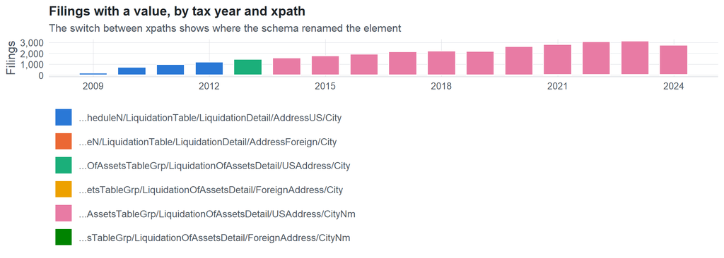

**Table view**

Table view: filings by tax year and series

| Tax year | …heduleN/LiquidationTable/LiquidationDetail/AddressUS/City | …eN/LiquidationTable/LiquidationDetail/AddressForeign/City | …OfAssetsTableGrp/LiquidationOfAssetsDetail/USAddress/City | …etsTableGrp/LiquidationOfAssetsDetail/ForeignAddress/City | …AssetsTableGrp/LiquidationOfAssetsDetail/USAddress/CityNm | …sTableGrp/LiquidationOfAssetsDetail/ForeignAddress/CityNm |
| --- | --- | --- | --- | --- | --- | --- |
| 2009 | 164 | 0 | 0 | 0 | 0 | 0 |
| 2010 | 689 | 4 | 0 | 0 | 0 | 0 |
| 2011 | 951 | 3 | 0 | 0 | 0 | 0 |
| 2012 | 1,176 | 5 | 0 | 0 | 0 | 0 |
| 2013 | 0 | 0 | 1,429 | 7 | 0 | 0 |
| 2014 | 0 | 0 | 0 | 0 | 1,557 | 11 |
| 2015 | 0 | 0 | 0 | 0 | 1,751 | 13 |
| 2016 | 0 | 0 | 0 | 0 | 1,886 | 12 |
| 2017 | 0 | 0 | 0 | 0 | 2,128 | 14 |
| 2018 | 0 | 0 | 0 | 0 | 2,180 | 13 |
| 2019 | 0 | 0 | 0 | 0 | 2,153 | 11 |
| 2020 | 0 | 0 | 0 | 0 | 2,601 | 17 |
| 2021 | 0 | 0 | 0 | 0 | 2,764 | 33 |
| 2022 | 0 | 0 | 0 | 0 | 3,011 | 28 |
| 2023 | 0 | 0 | 0 | 0 | 3,096 | 28 |
| 2024 | 0 | 0 | 0 | 0 | 2,690 | 30 |

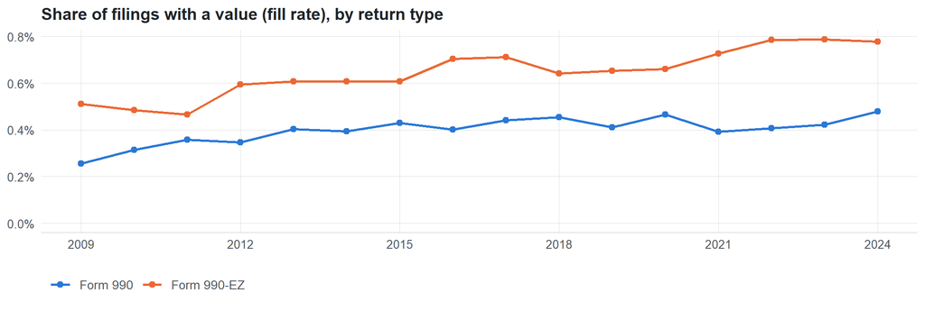

**Table view**

Table view: fill rate

| Tax year | Return type | Filings | All filings | Fill rate |
| --- | --- | --- | --- | --- |
| 2009 | Form 990 | 85 | 33,311 | 0.26% |
| 2009 | Form 990-EZ | 79 | 15,470 | 0.51% |
| 2010 | Form 990 | 386 | 123,025 | 0.31% |
| 2010 | Form 990-EZ | 307 | 63,326 | 0.48% |
| 2011 | Form 990 | 572 | 159,504 | 0.36% |
| 2011 | Form 990-EZ | 382 | 82,048 | 0.47% |
| 2012 | Form 990 | 623 | 179,688 | 0.35% |
| 2012 | Form 990-EZ | 558 | 93,750 | 0.60% |
| 2013 | Form 990 | 801 | 198,855 | 0.40% |
| 2013 | Form 990-EZ | 635 | 104,375 | 0.61% |
| 2014 | Form 990 | 861 | 218,619 | 0.39% |
| 2014 | Form 990-EZ | 707 | 116,417 | 0.61% |
| 2015 | Form 990 | 1,005 | 233,519 | 0.43% |
| 2015 | Form 990-EZ | 759 | 124,894 | 0.61% |
| 2016 | Form 990 | 979 | 243,903 | 0.40% |
| 2016 | Form 990-EZ | 919 | 130,484 | 0.70% |
| 2017 | Form 990 | 1,152 | 261,612 | 0.44% |
| 2017 | Form 990-EZ | 990 | 139,144 | 0.71% |
| 2018 | Form 990 | 1,234 | 271,442 | 0.45% |
| 2018 | Form 990-EZ | 959 | 149,384 | 0.64% |
| 2019 | Form 990 | 1,168 | 283,694 | 0.41% |
| 2019 | Form 990-EZ | 996 | 152,622 | 0.65% |
| 2020 | Form 990 | 1,495 | 320,342 | 0.47% |
| 2020 | Form 990-EZ | 1,123 | 169,864 | 0.66% |
| 2021 | Form 990 | 1,322 | 336,480 | 0.39% |
| 2021 | Form 990-EZ | 1,475 | 202,724 | 0.73% |
| 2022 | Form 990 | 1,419 | 349,055 | 0.41% |
| 2022 | Form 990-EZ | 1,620 | 206,130 | 0.79% |
| 2023 | Form 990 | 1,498 | 354,768 | 0.42% |
| 2023 | Form 990-EZ | 1,626 | 206,379 | 0.79% |
| 2024 | Form 990 | 1,329 | 277,298 | 0.48% |
| 2024 | Form 990-EZ | 1,391 | 178,867 | 0.78% |

## Repeating groups

Table cardinality in the concordance: **many**. 6 of 6 observed xpaths repeat within a filing.

Repeating element each xpath was observed in (from the raw indexed xpath)

| Xpath | Repeating element | Filings (summed over years) |
| --- | --- | --- |
| IRS990ScheduleN/LiquidationTable/LiquidationDetail/AddressUS/City | (none) | 1877 |
| IRS990ScheduleN/LiquidationTable/LiquidationDetail/AddressUS/City | IRS990ScheduleN/LiquidationTable/LiquidationDetail | 1103 |
| IRS990ScheduleN/LiquidationTable/LiquidationDetail/AddressForeign/City | (none) | 7 |
| IRS990ScheduleN/LiquidationTable/LiquidationDetail/AddressForeign/City | IRS990ScheduleN/LiquidationTable/LiquidationDetail | 5 |
| IRS990ScheduleN/LiquidationOfAssetsTableGrp/LiquidationOfAssetsDetail/ForeignAddress/City | (none) | 3 |
| IRS990ScheduleN/LiquidationOfAssetsTableGrp/LiquidationOfAssetsDetail/ForeignAddress/City | IRS990ScheduleN/LiquidationOfAssetsTableGrp/LiquidationOfAssetsDetail | 4 |
| IRS990ScheduleN/LiquidationOfAssetsTableGrp/LiquidationOfAssetsDetail/USAddress/City | (none) | 869 |
| IRS990ScheduleN/LiquidationOfAssetsTableGrp/LiquidationOfAssetsDetail/USAddress/City | IRS990ScheduleN/LiquidationOfAssetsTableGrp/LiquidationOfAssetsDetail | 560 |
| IRS990ScheduleN/LiquidationOfAssetsTableGrp/LiquidationOfAssetsDetail/ForeignAddress/CityNm | (none) | 126 |
| IRS990ScheduleN/LiquidationOfAssetsTableGrp/LiquidationOfAssetsDetail/ForeignAddress/CityNm | IRS990ScheduleN/LiquidationOfAssetsTableGrp/LiquidationOfAssetsDetail | 84 |
| IRS990ScheduleN/LiquidationOfAssetsTableGrp/LiquidationOfAssetsDetail/USAddress/CityNm | (none) | 16933 |
| IRS990ScheduleN/LiquidationOfAssetsTableGrp/LiquidationOfAssetsDetail/USAddress/CityNm | IRS990ScheduleN/LiquidationOfAssetsTableGrp/LiquidationOfAssetsDetail | 8884 |

## Values

[output not shown]

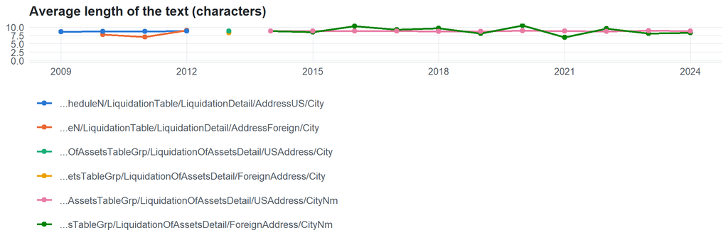

**Table view**

Table view: length and variety by tax year

| Series | Tax year | Filings | Avg length | Max length | Distinct values (approx.) |
| --- | --- | --- | --- | --- | --- |
| …heduleN/LiquidationTable/LiquidationDetail/AddressUS/City | 2009 | 164 | 9 | 17 | 91 |
| …heduleN/LiquidationTable/LiquidationDetail/AddressUS/City | 2010 | 689 | 9 | 19 | 197 |
| …heduleN/LiquidationTable/LiquidationDetail/AddressUS/City | 2011 | 951 | 9 | 18 | 359 |
| …heduleN/LiquidationTable/LiquidationDetail/AddressUS/City | 2012 | 1,176 | 9 | 19 | 346 |
| …eN/LiquidationTable/LiquidationDetail/AddressForeign/City | 2010 | 4 | 8 | 10 | 1 |
| …eN/LiquidationTable/LiquidationDetail/AddressForeign/City | 2011 | 3 | 7 | 8 | 2 |
| …eN/LiquidationTable/LiquidationDetail/AddressForeign/City | 2012 | 5 | 9 | 12 | 4 |
| …OfAssetsTableGrp/LiquidationOfAssetsDetail/USAddress/City | 2013 | 1,429 | 9 | 22 | 362 |
| …etsTableGrp/LiquidationOfAssetsDetail/ForeignAddress/City | 2013 | 7 | 8 | 13 | 3 |
| …AssetsTableGrp/LiquidationOfAssetsDetail/USAddress/CityNm | 2014 | 1,557 | 9 | 20 | 635 |
| …AssetsTableGrp/LiquidationOfAssetsDetail/USAddress/CityNm | 2015 | 1,751 | 9 | 20 | 476 |
| …AssetsTableGrp/LiquidationOfAssetsDetail/USAddress/CityNm | 2016 | 1,886 | 9 | 22 | 674 |
| …AssetsTableGrp/LiquidationOfAssetsDetail/USAddress/CityNm | 2017 | 2,128 | 9 | 20 | 716 |
| …AssetsTableGrp/LiquidationOfAssetsDetail/USAddress/CityNm | 2018 | 2,180 | 9 | 22 | 748 |
| …AssetsTableGrp/LiquidationOfAssetsDetail/USAddress/CityNm | 2019 | 2,153 | 9 | 22 | 496 |
| …AssetsTableGrp/LiquidationOfAssetsDetail/USAddress/CityNm | 2020 | 2,601 | 9 | 22 | 670 |
| …AssetsTableGrp/LiquidationOfAssetsDetail/USAddress/CityNm | 2021 | 2,764 | 9 | 20 | 685 |
| …AssetsTableGrp/LiquidationOfAssetsDetail/USAddress/CityNm | 2022 | 3,011 | 9 | 21 | 1,099 |
| …AssetsTableGrp/LiquidationOfAssetsDetail/USAddress/CityNm | 2023 | 3,096 | 9 | 22 | 661 |
| …AssetsTableGrp/LiquidationOfAssetsDetail/USAddress/CityNm | 2024 | 2,690 | 9 | 22 | 751 |
| …sTableGrp/LiquidationOfAssetsDetail/ForeignAddress/CityNm | 2014 | 11 | 9 | 17 | 7 |
| …sTableGrp/LiquidationOfAssetsDetail/ForeignAddress/CityNm | 2015 | 13 | 8 | 17 | 7 |
| …sTableGrp/LiquidationOfAssetsDetail/ForeignAddress/CityNm | 2016 | 12 | 10 | 17 | 11 |
| …sTableGrp/LiquidationOfAssetsDetail/ForeignAddress/CityNm | 2017 | 14 | 9 | 17 | 4 |
| …sTableGrp/LiquidationOfAssetsDetail/ForeignAddress/CityNm | 2018 | 13 | 10 | 19 | 6 |
| …sTableGrp/LiquidationOfAssetsDetail/ForeignAddress/CityNm | 2019 | 11 | 8 | 14 | 4 |
| …sTableGrp/LiquidationOfAssetsDetail/ForeignAddress/CityNm | 2020 | 17 | 11 | 30 | 18 |
| …sTableGrp/LiquidationOfAssetsDetail/ForeignAddress/CityNm | 2021 | 33 | 7 | 18 | 58 |
| …sTableGrp/LiquidationOfAssetsDetail/ForeignAddress/CityNm | 2022 | 28 | 10 | 27 | 15 |
| …sTableGrp/LiquidationOfAssetsDetail/ForeignAddress/CityNm | 2023 | 28 | 8 | 16 | 7 |
| …sTableGrp/LiquidationOfAssetsDetail/ForeignAddress/CityNm | 2024 | 30 | 8 | 16 | 16 |

Most common values by xpath (all years; long values truncated)

| Series | Value | Filings | Share |
| --- | --- | --- | --- |
| …heduleN/LiquidationTable/LiquidationDetail/AddressUS/City | NEW YORK | 58 | 1.9% |
| …heduleN/LiquidationTable/LiquidationDetail/AddressUS/City | WASHINGTON | 49 | 1.6% |
| …heduleN/LiquidationTable/LiquidationDetail/AddressUS/City | BOSTON | 33 | 1.1% |
| …heduleN/LiquidationTable/LiquidationDetail/AddressUS/City |  | 24 | 0.8% |
| …heduleN/LiquidationTable/LiquidationDetail/AddressUS/City | ST LOUIS | 24 | 0.8% |
| …heduleN/LiquidationTable/LiquidationDetail/AddressUS/City | COLUMBUS | 23 | 0.8% |
| …heduleN/LiquidationTable/LiquidationDetail/AddressUS/City | SEATTLE | 23 | 0.8% |
| …heduleN/LiquidationTable/LiquidationDetail/AddressUS/City | CINCINNATI | 21 | 0.7% |
| …heduleN/LiquidationTable/LiquidationDetail/AddressUS/City | PHILADELPHIA | 20 | 0.7% |
| …heduleN/LiquidationTable/LiquidationDetail/AddressUS/City | SAN FRANCISCO | 18 | 0.6% |
| …heduleN/LiquidationTable/LiquidationDetail/AddressUS/City | BRAINTREE | 18 | 0.6% |
| …heduleN/LiquidationTable/LiquidationDetail/AddressUS/City | CHICAGO | 17 | 0.6% |
| …heduleN/LiquidationTable/LiquidationDetail/AddressUS/City | ATLANTA | 13 | 0.4% |
| …heduleN/LiquidationTable/LiquidationDetail/AddressUS/City | DENVER | 11 | 0.4% |
| …heduleN/LiquidationTable/LiquidationDetail/AddressUS/City | LOS ANGELES | 11 | 0.4% |
| …heduleN/LiquidationTable/LiquidationDetail/AddressUS/City | BELLEVILLE | 10 | 0.3% |
| …heduleN/LiquidationTable/LiquidationDetail/AddressUS/City | MINNEAPOLIS | 9 | 0.3% |
| …heduleN/LiquidationTable/LiquidationDetail/AddressUS/City | MIAMI | 9 | 0.3% |
| …heduleN/LiquidationTable/LiquidationDetail/AddressUS/City | BALTIMORE | 8 | 0.3% |
| …heduleN/LiquidationTable/LiquidationDetail/AddressUS/City | DAYTONA BEACH | 4 | 0.1% |
| …heduleN/LiquidationTable/LiquidationDetail/AddressUS/City | new york | 3 | 0.1% |
| …heduleN/LiquidationTable/LiquidationDetail/AddressUS/City | ASHEVILLE | 2 | 0.1% |
| …heduleN/LiquidationTable/LiquidationDetail/AddressUS/City | DETROIT | 2 | 0.1% |
| …heduleN/LiquidationTable/LiquidationDetail/AddressUS/City | Houston | 2 | 0.1% |
| …eN/LiquidationTable/LiquidationDetail/AddressForeign/City | BEAUMONT | 1 | 8.3% |
| …eN/LiquidationTable/LiquidationDetail/AddressForeign/City | BIG RAPIDS | 1 | 8.3% |
| …eN/LiquidationTable/LiquidationDetail/AddressForeign/City | CHICAGO | 1 | 8.3% |
| …eN/LiquidationTable/LiquidationDetail/AddressForeign/City | Nassau | 1 | 8.3% |
| …eN/LiquidationTable/LiquidationDetail/AddressForeign/City | BELARUS | 1 | 8.3% |
| …eN/LiquidationTable/LiquidationDetail/AddressForeign/City | FREETOWN | 1 | 8.3% |

First rows shown.

## Examples

| Tax year | Return | Xpath | Organization | Value | Source |
| --- | --- | --- | --- | --- | --- |
| 2024 | 990 | IRS990ScheduleN/LiquidationOfAssetsTableGrp/LiquidationOfAssetsDetail/ForeignAddress/CityNm | TWG 2021 BIRMINGHAM FOUNDATION | LAUSANNE | [XML](https://gt990datalake-rawdata.s3.amazonaws.com/EfileData/XmlFiles/202510519349301031_public.xml) |
| 2024 | 990 | IRS990ScheduleN/LiquidationOfAssetsTableGrp/LiquidationOfAssetsDetail/USAddress/CityNm | BIG BROTHERS BIG SISTERS OF ISLAND COUNTY | OAK HARBOR | [XML](https://gt990datalake-rawdata.s3.amazonaws.com/EfileData/XmlFiles/202620289349301652_public.xml) |
| 2023 | 990EZ | IRS990ScheduleN/LiquidationOfAssetsTableGrp/LiquidationOfAssetsDetail/ForeignAddress/CityNm | BLANCHARDS ANGUILLA CHILDRENS FUND INC | THE VALLEY | [XML](https://gt990datalake-rawdata.s3.amazonaws.com/EfileData/XmlFiles/202402149349200345_public.xml) |
| 2023 | 990EZ | IRS990ScheduleN/LiquidationOfAssetsTableGrp/LiquidationOfAssetsDetail/USAddress/CityNm | CAREGIVERS JOURNAL | Saint George | [XML](https://gt990datalake-rawdata.s3.amazonaws.com/EfileData/XmlFiles/202400489349200020_public.xml) |
| 2022 | 990EZ | IRS990ScheduleN/LiquidationOfAssetsTableGrp/LiquidationOfAssetsDetail/ForeignAddress/CityNm | GHANA COMMUNITY PATHWAYS | Kaare | [XML](https://gt990datalake-rawdata.s3.amazonaws.com/EfileData/XmlFiles/202301259349202115_public.xml) |
| 2022 | 990 | IRS990ScheduleN/LiquidationOfAssetsTableGrp/LiquidationOfAssetsDetail/USAddress/CityNm | ARCHBOLD HEALTH SERVICES INC | THOMASVILLE | [XML](https://gt990datalake-rawdata.s3.amazonaws.com/EfileData/XmlFiles/202302729349300005_public.xml) |
| 2021 | 990EZ | IRS990ScheduleN/LiquidationOfAssetsTableGrp/LiquidationOfAssetsDetail/ForeignAddress/CityNm | CONSOURCE INC | St Aldates | [XML](https://gt990datalake-rawdata.s3.amazonaws.com/EfileData/XmlFiles/202213079349201101_public.xml) |
| 2021 | 990EZ | IRS990ScheduleN/LiquidationOfAssetsTableGrp/LiquidationOfAssetsDetail/USAddress/CityNm | GREATER CINCINNATI GOLF ASSOCIATION | CINCINNATI | [XML](https://gt990datalake-rawdata.s3.amazonaws.com/EfileData/XmlFiles/202212359349200321_public.xml) |
| 2020 | 990 | IRS990ScheduleN/LiquidationOfAssetsTableGrp/LiquidationOfAssetsDetail/ForeignAddress/CityNm | OSGI ALLIANCE INC | OTTAWA | [XML](https://gt990datalake-rawdata.s3.amazonaws.com/EfileData/XmlFiles/202131169349301333_public.xml) |
| 2020 | 990 | IRS990ScheduleN/LiquidationOfAssetsTableGrp/LiquidationOfAssetsDetail/USAddress/CityNm | CATAPULT CHICAGO | CHICAGO | [XML](https://gt990datalake-rawdata.s3.amazonaws.com/EfileData/XmlFiles/202100969349301755_public.xml) |
| 2019 | 990EZ | IRS990ScheduleN/LiquidationOfAssetsTableGrp/LiquidationOfAssetsDetail/ForeignAddress/CityNm | Gandhi Worldwide Education Institute | Kolhapur | [XML](https://gt990datalake-rawdata.s3.amazonaws.com/EfileData/XmlFiles/202013529349200411_public.xml) |
| 2019 | 990 | IRS990ScheduleN/LiquidationOfAssetsTableGrp/LiquidationOfAssetsDetail/USAddress/CityNm | JOBE | LOS ANGELES | [XML](https://gt990datalake-rawdata.s3.amazonaws.com/EfileData/XmlFiles/202011139349301211_public.xml) |

## Reviewer checklist

- The definition matches the form line and instructions for every xpath’s schema years.
- Every xpath pooled here measures the same thing on the 990 and 990-EZ (close enough for analysis).
- The coverage chart has no unexplained gaps or jumps between tax years.
- Each open flag is fixed, or accepted with a note in validation_log.csv.
- Values answer the question on the form line (not another line’s explanation).
- Boilerplate such as ‘See Schedule O’ or ‘N/A’ is expected here, or should be treated as missing.
- Text that is really a number or a code is flagged for a different data type.

Record the review as a row in `inst/extdata/src/validation_log.csv` (variable_name, reviewer, date, status, note). Evidence built 2026-09-23 17:09:04 MST from the ef2 DuckDB builds (tax years 2009–2024).